# HW4

Mark Mitri

09/12/2022

Instructions: Submit an R notebook that does what each of the following questions requires.

Linear models

1. (3 points)

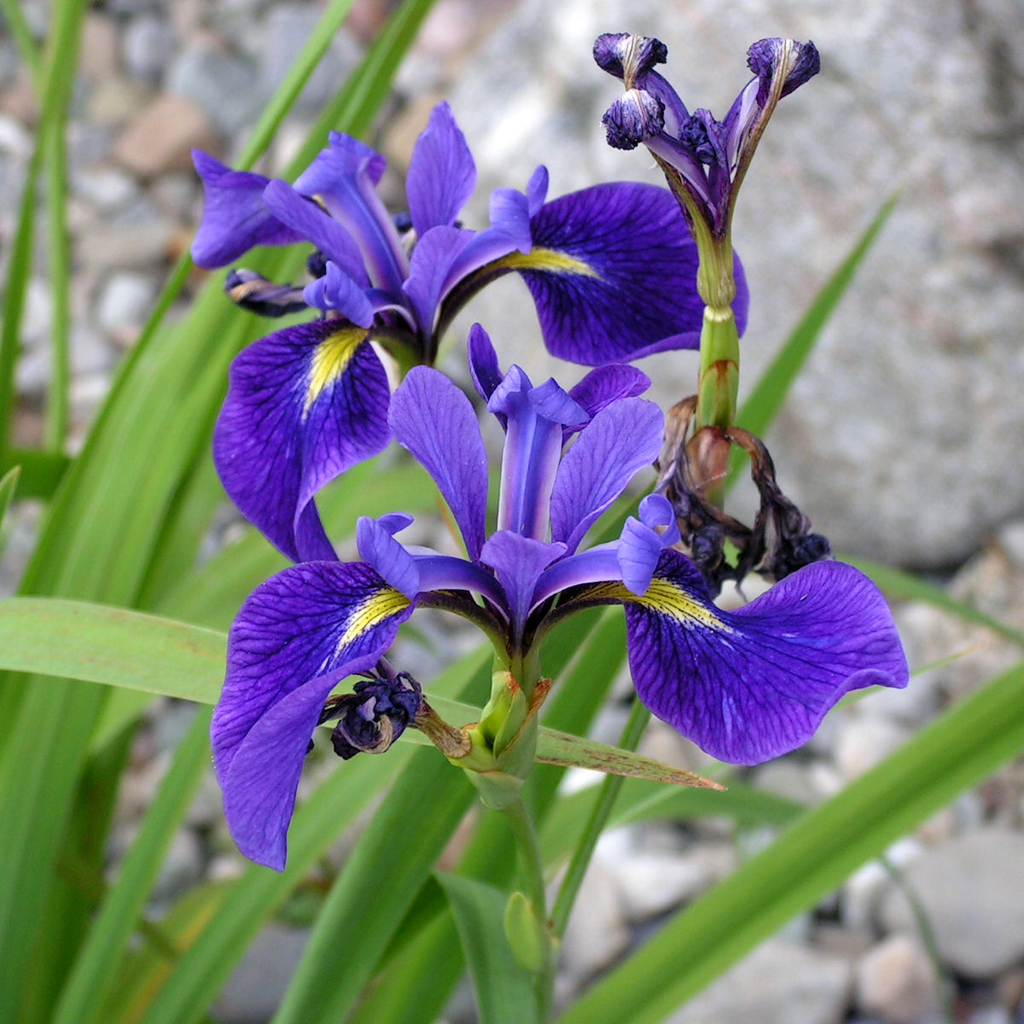

The versicolor iris

We have seen the Iris dataset previously. Make a copy of the iris dataframe, and with the copy, create a new column called “class” that is TRUE when Species matches “versicolor” and FALSE otherwise. Then delete the Species column. This sets up the data to be used in building a versicolor classifier.

```r
irisCopy <- data.frame(iris)
irisCopy$class <- ifelse(irisCopy$Species == "versicolor", irisCopy$class <- TRUE, irisCopy$class <- FALSE)
irisCopy$Species <- NULL
irisCopy
```

| Sepal.Length | Sepal.Width | Petal.Length | Petal.Width | class |
| --- | --- | --- | --- | --- |
| 5.1 | 3.5 | 1.4 | 0.2 | FALSE |
| 4.9 | 3.0 | 1.4 | 0.2 | FALSE |
| 4.7 | 3.2 | 1.3 | 0.2 | FALSE |
| 4.6 | 3.1 | 1.5 | 0.2 | FALSE |
| 5.0 | 3.6 | 1.4 | 0.2 | FALSE |
| 5.4 | 3.9 | 1.7 | 0.4 | FALSE |
| 4.6 | 3.4 | 1.4 | 0.3 | FALSE |
| 5.0 | 3.4 | 1.5 | 0.2 | FALSE |
| 4.4 | 2.9 | 1.4 | 0.2 | FALSE |
| 4.9 | 3.1 | 1.5 | 0.1 | FALSE |

[output cut: 140 more lines]

Now build a logistic regression model using the dataframe you have created. Use that model to predict the probability of the class variable for the data used in training.

```r
#YOUR CODE GOES HERE
logModel <- glm(irisCopy$class ~ irisCopy$Sepal.Length + irisCopy$Sepal.Width + irisCopy$Petal.Length + irisCopy$Petal.Width, family = binomial);
summary(logModel)
```

```
Call:
glm(formula = irisCopy$class ~ irisCopy$Sepal.Length + irisCopy$Sepal.Width +
    irisCopy$Petal.Length + irisCopy$Petal.Width, family = binomial)

Deviance Residuals:
    Min       1Q   Median       3Q      Max
-2.1280  -0.7668  -0.3818   0.7866   2.1202

Coefficients:
                      Estimate Std. Error z value Pr(>|z|)
(Intercept)             7.3785     2.4993   2.952 0.003155 **
irisCopy$Sepal.Length  -0.2454     0.6496  -0.378 0.705634
irisCopy$Sepal.Width   -2.7966     0.7835  -3.569 0.000358 ***
irisCopy$Petal.Length   1.3136     0.6838   1.921 0.054713 .
irisCopy$Petal.Width   -2.7783     1.1731  -2.368 0.017868 *
---
Signif. codes:  0 ‘***’ 0.001 ‘**’ 0.01 ‘*’ 0.05 ‘.’ 0.1 ‘ ’ 1

(Dispersion parameter for binomial family taken to be 1)

    Null deviance: 190.95  on 149  degrees of freedom
Residual deviance: 145.07  on 145  degrees of freedom
AIC: 155.07

Number of Fisher Scoring iterations: 5
```

```r
logModelPred <- predict(logModel, type = "response")
logModelPred[1:5]
```

```
         1          2          3          4          5
0.08491322 0.28291787 0.17198267 0.26801458 0.06707520
```

Now convert the predicted probability vector into a class prediction vector (using a threshold). Compare the class prediction vector with the actual class labels and calculate the accuracy of this model (e.g., how well it has learned the training data).

```r
#YOUR CODE GOES HERE
# .4 threshold
threshold <- .4
classPred <- logModelPred > threshold
count <- 0
index <- 1
for(x in irisCopy$class){
  if(x == classPred[index]){
    count <- count + 1
  }
  index <- index + 1
}
accuracy <- count/length(irisCopy$class)
accuracy
```

```
[1] 0.76
```

2. (2 points)

Let’s see if we can improve the performance you found above. Add a new feature that is a nonlinear combination of one or more existing features. Rebuild your model and evaluate it. Does it perform better?

```r
#YOUR CODE GOES HERE
irisCopy$Sepal.Width2 <- (irisCopy$Sepal.Width)^2
logModel2 <- glm(irisCopy$class ~ irisCopy$Sepal.Length + irisCopy$Sepal.Width + irisCopy$Petal.Length + irisCopy$Petal.Width + irisCopy$Sepal.Width2, family = binomial)
logModelPred2 <- predict(logModel2, type = "response")

threshold <- .4
classPred2 <- logModelPred2 > threshold
count <- 0
index <- 1
for(x in irisCopy$class){
  if(x == classPred2[index]){
    count <- count + 1
  }
  index <- index + 1
}
accuracy <- count/length(irisCopy$class)
accuracy
```

```
[1] 0.7466667
```

Add a second nonlinear feature. Can it improve things further?

```r
#YOUR CODE GOES HERE
irisCopy$WidthLength <- (irisCopy$Sepal.Width)*(irisCopy$Petal.Length)
logModel3 <- glm(irisCopy$class ~ irisCopy$Sepal.Length + irisCopy$Sepal.Width + irisCopy$Petal.Length + irisCopy$Petal.Width + irisCopy$Sepal.Width2 + irisCopy$WidthLength, family = binomial)
logModelPred3 <- predict(logModel3, type = "response")

threshold <- .4
classPred3 <- logModelPred3 > threshold
count <- 0
index <- 1
for(x in irisCopy$class){
  if(x == classPred3[index]){
    count <- count + 1
  }
  index <- index + 1
}
accuracy <- count/length(irisCopy$class)
accuracy
```

```
[1] 0.8
```

3. (2 points)

Install the library “e1071”. Use the `svm()` function with a basic “linear” kernel and `type="C-classification"` and perform the same versicolor classification task as above. How does it compare?

```r
#install.packages("e1071")
library(e1071)
#YOUR CODE GOES HERE
svModel <- svm(irisCopy$class ~ irisCopy$Sepal.Length + irisCopy$Sepal.Width + irisCopy$Petal.Length + irisCopy$Petal.Width + irisCopy$Sepal.Width2 + irisCopy$WidthLength, type = "C-classification")
svModelPred <- predict(svModel, type = "response")

threshold <- .4
classPred3 <- svModelPred > threshold
count <- 0
index <- 1
for(x in irisCopy$class){
  if(x == svModelPred[index]){
    count <- count + 1
  }
  index <- index + 1
}
accuracy <- count/length(irisCopy$class)
accuracy
```

```
[1] 0.9733333
```

What if you use a different kernel? Can you get significantly better performance?

```r
#YOUR CODE GOES HERE
svModel <- svm(irisCopy$class ~ irisCopy$Sepal.Length + irisCopy$Sepal.Width + irisCopy$Petal.Length + irisCopy$Petal.Width + irisCopy$Sepal.Width2 + irisCopy$WidthLength, type = "C-classification", kernel = "polynomial")
svModelPred <- predict(svModel, type = "response")

threshold <- .4
classPred3 <- svModelPred > threshold
count <- 0
index <- 1
for(x in irisCopy$class){
  if(x == svModelPred[index]){
    count <- count + 1
  }
  index <- index + 1
}
accuracy <- count/length(irisCopy$class)
accuracy
```

```
[1] 0.7133333
```

4. (2 points)

Do you think it that Sepal.Length is predictable as a function of class and the other three measurements? (We will not use the non-linear features for the moment.) Let’s build a simple linear regression model using these original features. This also uses `glm()` but using the default `gaussian` family. Generate the vector of predicted values (same as before).

```r
#YOUR CODE GOES HERE
SepalMod <- glm(irisCopy$Sepal.Length ~ irisCopy$class + irisCopy$Sepal.Width + irisCopy$Petal.Length + irisCopy$Petal.Width, family = gaussian);
summary(SepalMod)
```

```
Call:
glm(formula = irisCopy$Sepal.Length ~ irisCopy$class + irisCopy$Sepal.Width +
    irisCopy$Petal.Length + irisCopy$Petal.Width, family = gaussian)

Deviance Residuals:
     Min        1Q    Median        3Q       Max
-0.83408  -0.22323   0.01788   0.19554   0.84202

Coefficients:
                      Estimate Std. Error t value Pr(>|t|)
(Intercept)            1.87420    0.26999   6.942 1.20e-10 ***
irisCopy$classTRUE    -0.01182    0.06360  -0.186    0.853
irisCopy$Sepal.Width   0.64541    0.07296   8.847 2.84e-15 ***
irisCopy$Petal.Length  0.71157    0.05840  12.184  < 2e-16 ***
irisCopy$Petal.Width  -0.56219    0.13161  -4.272 3.49e-05 ***
---
Signif. codes:  0 ‘***’ 0.001 ‘**’ 0.01 ‘*’ 0.05 ‘.’ 0.1 ‘ ’ 1

(Dispersion parameter for gaussian family taken to be 0.09959974)

    Null deviance: 102.168  on 149  degrees of freedom
Residual deviance:  14.442  on 145  degrees of freedom
AIC: 86.607

Number of Fisher Scoring iterations: 2
```

```r
SepalModPred <- predict(SepalMod, type = "response")
SepalModPred[1:5]
```

```
       1        2        3        4        5
5.016910 4.694204 4.752129 4.829902 5.081452
```

But how should we evaluate linear regression? We can’t use accuracy because we don’t have class predictions. A common metric is root mean squared error, defined as `sqrt(mean((firstvector - secondvector)^2))`. Since it is an error measure, the smaller the value you get, the better it is. What RMSE do you get for this linear regression model?

```r
#YOUR CODE GOES HERE
SepalPredError <- sqrt(mean((SepalModPred-irisCopy$Sepal.Length)^2))
SepalPredError
```

```
[1] 0.3102898
```

5. (1 point)

Can you improve upon the performance in question 4 when adding the two non-linear variables from question 2?

```r
#YOUR CODE GOES HERE
SepalMod <- glm(irisCopy$Sepal.Length ~ irisCopy$class + irisCopy$Sepal.Width + irisCopy$Petal.Length + irisCopy$Petal.Width + irisCopy$Sepal.Width2 + irisCopy$WidthLength, family = gaussian);
SepalModPred <- predict(SepalMod, type = "response")

threshold <- .4
classPred4 <- SepalModPred > threshold
count <- 0
index <- 1
for(x in irisCopy$Sepal.Length){
  if(x == SepalModPred[index]){
    count <- count + 1
  }
  index <- index + 1
}

SepalPredError2 <- sqrt(mean((SepalModPred-irisCopy$Sepal.Length)^2))
SepalPredError2
```

```
[1] 0.3082182
```